# Blood Pressure

### On Blood Pressure

On the first day blood pressure is elevated:

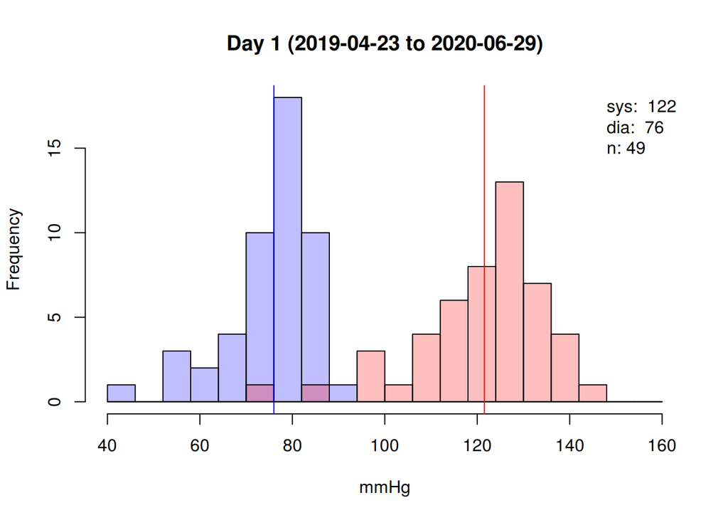

```r
plot.blood.pressure(nth.day.after(0), "Day 1")
```

On day 2 it has subsided a bit:

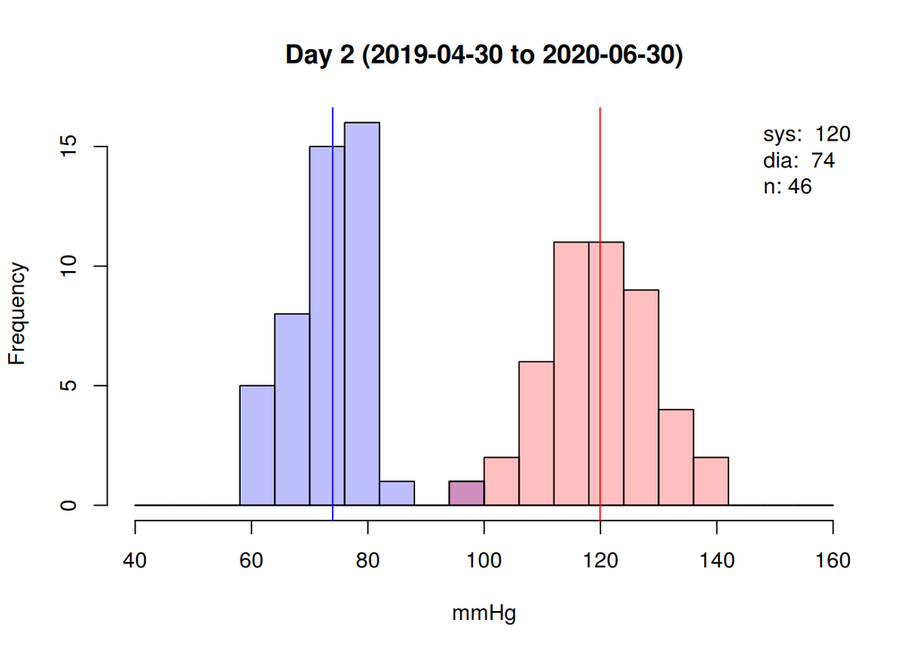

```r
plot.blood.pressure(nth.day.after(1), "Day 2")
```

On day 3 it is further reduced:

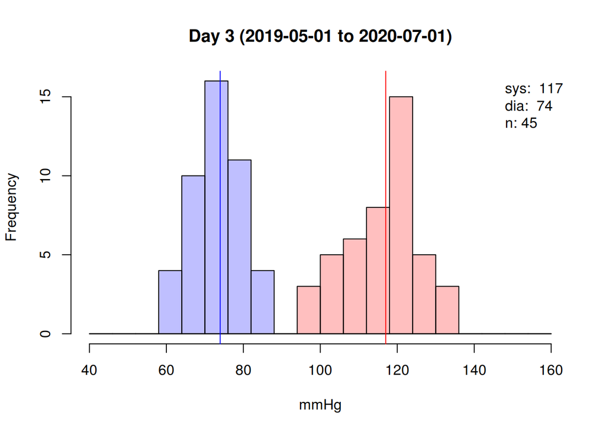

```r
plot.blood.pressure(nth.day.after(2), "Day 3")
```

On the fourth day it is reduced still further:

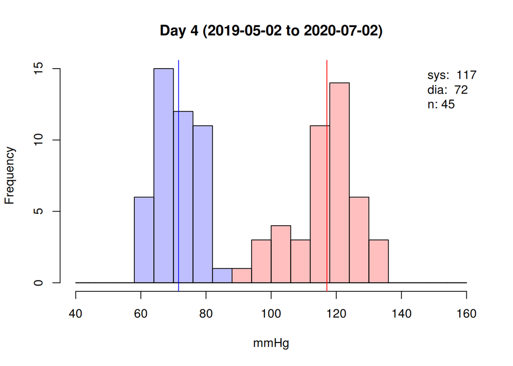

```r
plot.blood.pressure(nth.day.after(3), "Day 4")
```

On the fifth day it has more-or-less returned to normal:

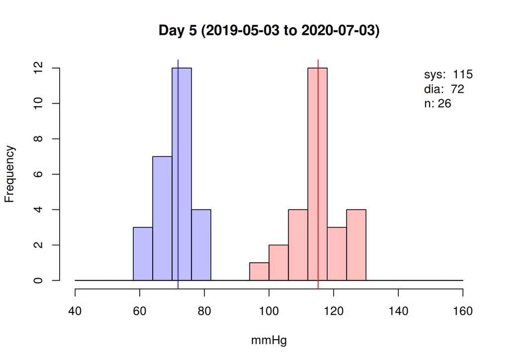

```r
plot.blood.pressure(nth.day.after(4), "Day 5")
```

### On Pulse

On the first day pulse is raised:

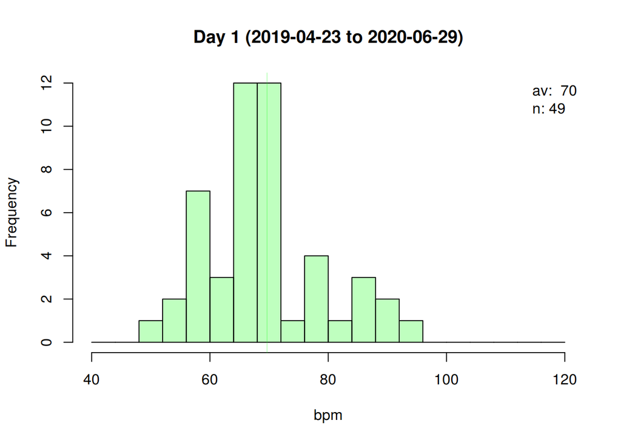

```r
plot.pulse(nth.day.after(0), "Day 1")
```

On the second day it is lowered:

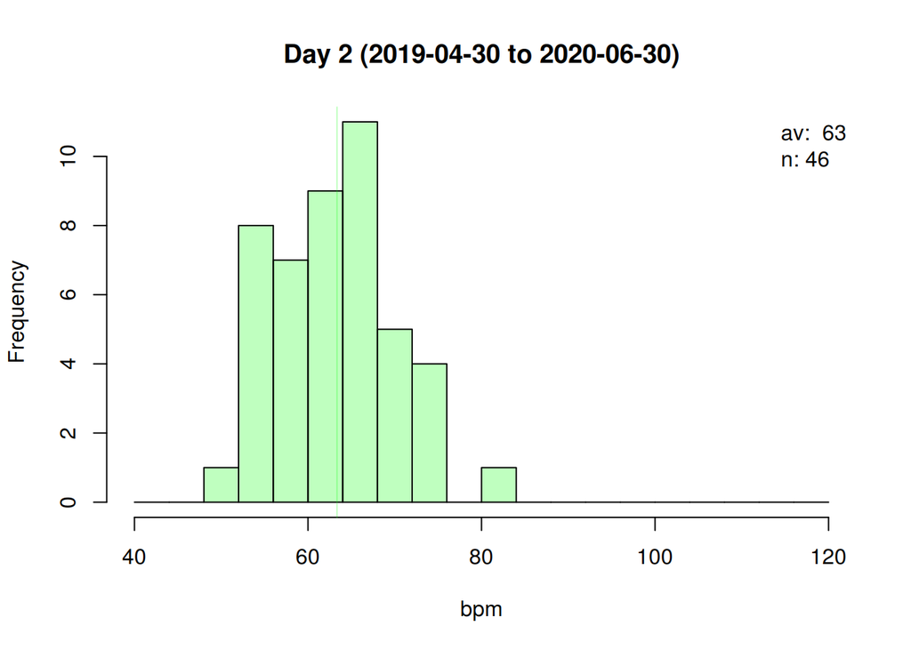

```r
plot.pulse(nth.day.after(1), "Day 2")
```

By day 3 it has returned to normal:

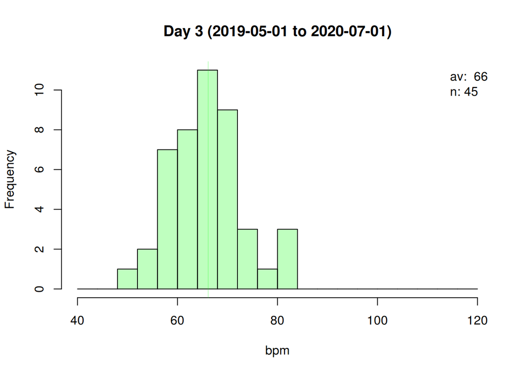

```r
plot.pulse(nth.day.after(2), "Day 3")
```

### Discussion

The model is complicated by the fact that alcohol tended to be consumed on consecutive days, when it was consumed:

```r
dates <- f[f$alcohol == 1, "date"]
length(dates[diff(dates) == -1]) / length(dates)
```

```
## [1] 0.6790123
```

To deal with this, the model considers consecutive days as a single day. It looks for days on which alcohol was consumed, followed by days on which it wasn’t. (Such days are “Day 1” in the graphs above.)

The numbers of days per each “day after” illustrate another pattern in the data:

```r
ns <- function(n) length(unique(nth.day.after(n)$date))
sapply(c(0, 1, 2, 3, 4, 5, 6), ns, simplify = T)
```

```
## [1] 27 23 23 23 13 12 13
```

On about half of the occasions when alcohol was consumed, it was also consumed 5 days later (e.g., a Sunday followed by a Friday). On most occasions when it was consumed, it was not consumed during the following 4 days (e.g., Monday to Thursday).

This is confirmed by looking at the days of the week on which it was consumed:

```r
table(wday(dates, label=T, abbr=T))
```

```
##
## Sun Mon Tue Wed Thu Fri Sat
##  21   7   4   5   5  19  20
```